# Lab 04 - Predicting MHV Change (Lab 06)

Erin McIntyre

11/24/2021

```r
# load necessary packages ----
library(import)
library( dplyr )
library( here )
library( knitr )
library( pander )
library( stargazer )
library( scales )
# set randomization seed ----
set.seed( 1234 )
# load necessary functions and objects ----
# note: all of these are R objects that will be used throughout this .rmd file
import::here("S_TYPE",
             "panel.cor",
             "panel.smooth",
             "jplot",
             "d",
             "df",
             "cbsa_stats_df",
             # notice the use of here::here() that points to the .R file
             # where all these R objects are created
             .from = here::here("labs/wk06/lab_06_source_em.R"),
             .character_only = TRUE)
```

# Part 1 - Data

```r
head(df) %>% pander()
```

Table continues below

| MedianHomeValue2000 | MedianHomeValue2010 | MHV.Change.00.to.10 |
| --- | --- | --- |
| 98703 | 121500 | 22797 |
| 93935 | 130500 | 36565 |
| 102955 | 118700 | 15745 |
| 115712 | 133500 | 17788 |
| 150237 | 174500 | 24263 |
| 90714 | 129600 | 38886 |

| MHV.Growth.00.to.12 |
| --- |
| 23.1 |
| 38.93 |
| 15.29 |
| 15.37 |
| 16.15 |
| 42.87 |

```r
head(d) %>% pander()
```

Table continues below

| tractid | cbsa | cbsaname | mhv.00 | mhv.10 | mhv.change |
| --- | --- | --- | --- | --- | --- |
| fips-01-001-020100 | 33860 | Montgomery, AL | 98703 | 121500 | 22797 |
| fips-01-001-020200 | 33860 | Montgomery, AL | 93935 | 130500 | 36565 |
| fips-01-001-020300 | 33860 | Montgomery, AL | 102955 | 118700 | 15745 |
| fips-01-001-020400 | 33860 | Montgomery, AL | 115712 | 133500 | 17788 |
| fips-01-001-020500 | 33860 | Montgomery, AL | 150237 | 174500 | 24263 |
| fips-01-001-020600 | 33860 | Montgomery, AL | 90714 | 129600 | 38886 |

Table continues below

| mhv.growth | hinc00 | hu00 | own00 | rent00 | hinc12 | hu10 | own10 | rent10 |
| --- | --- | --- | --- | --- | --- | --- | --- | --- |
| 23.1 | 47270 | 769 | 518 | 158 | 56500 | 752 | 536 | 157 |
| 38.93 | 39040 | 731 | 452 | 212 | 41250 | 822 | 469 | 274 |
| 15.29 | 60215 | 1263 | 869 | 333 | 43088 | 1326 | 949 | 307 |
| 15.37 | 59456 | 1871 | 1390 | 370 | 54503 | 1823 | 1357 | 365 |
| 16.15 | 75878 | 2282 | 1671 | 531.3 | 65027 | 4308 | 2459 | 1623 |
| 42.87 | 43423 | 1310 | 960.9 | 209.2 | 52639 | 1452 | 1014 | 297 |

Table continues below

| empclf00 | clf00 | unemp00 | prof00 | empclf12 | clf12 | unemp12 | prof12 |
| --- | --- | --- | --- | --- | --- | --- | --- |
| 826 | 872 | 46 | 221 | 858 | 878 | 32 | 240 |
| 722 | 802 | 80 | 154 | 880 | 1010 | 134 | 352 |
| 1414 | 1456 | 42 | 438 | 1408 | 1423 | 36 | 437 |
| 2114 | 2191 | 77 | 673 | 1825 | 2005 | 206 | 596 |
| 2906 | 2955 | 49.35 | 1173 | 5037 | 5224 | 201 | 2123 |
| 1497 | 1584 | 87.18 | 364.2 | 1426 | 1583 | 177 | 370 |

Table continues below

| dpov00 | npov00 | dpov12 | npov12 | ag25up00 | hs00 | col00 | ag25up12 | hs12 |
| --- | --- | --- | --- | --- | --- | --- | --- | --- |
| 1790 | 227 | 1764 | 163 | 1227 | 635 | 192 | 1206 | 687 |
| 1907 | 433 | 2074 | 218 | 1157 | 740 | 170 | 1442 | 745 |
| 3262 | 250 | 3104 | 367 | 2130 | 990 | 478 | 2082 | 1006 |
| 4551 | 207 | 4337 | 136 | 3072 | 1477 | 708 | 2998 | 1242 |
| 6048 | 223.3 | 10431 | 807 | 3785 | 1257 | 1214 | 6351 | 1940 |
| 3272 | 497.9 | 3490 | 640 | 1977 | 1179 | 317.7 | 2136 | 1118 |

Table continues below

| col12 | pop00.x | nhwht00 | nhblk00 | hisp00 | asian00 | pop10 | nhwht10 |
| --- | --- | --- | --- | --- | --- | --- | --- |
| 287 | 1921 | 1723 | 145 | 12 | 8 | 1912 | 1601 |
| 349 | 1892 | 671 | 1177 | 16 | 12 | 2170 | 844 |
| 292 | 3339 | 2738 | 498 | 55 | 27 | 3373 | 2538 |
| 785 | 4556 | 4273 | 118 | 101 | 40 | 4386 | 4030 |
| 2569 | 6054 | 5427 | 367.5 | 95.24 | 113.1 | 10766 | 8438 |
| 438 | 3272 | 2615 | 553.1 | 63.93 | 10.65 | 3668 | 2672 |

Table continues below

| nhblk10 | hisp10 | asian10 | num.nmtc | nmtc.total | num.lihtc | lihtc.total |
| --- | --- | --- | --- | --- | --- | --- |
| 228 | 44 | 16 | 0 | 0 | 0 | 0 |
| 1226 | 75 | 13 | 0 | 0 | 0 | 0 |
| 668 | 87 | 42 | 0 | 0 | 1 | 2e+05 |
| 205 | 85 | 35 | 0 | 0 | 0 | 0 |
| 1504 | 355 | 373 | 0 | 0 | 2 | 1304122 |
| 776 | 176 | 19 | 0 | 0 | 0 | 0 |

Table continues below

| p.white.00 | p.black.00 | p.hisp.00 | p.asian.00 | p.hs.edu.00 | p.col.edu.00 |
| --- | --- | --- | --- | --- | --- |
| 89.69 | 7.548 | 0.6247 | 0.4164 | 67.4 | 15.65 |
| 35.47 | 62.21 | 0.8457 | 0.6342 | 78.65 | 14.69 |
| 82 | 14.91 | 1.647 | 0.8086 | 68.92 | 22.44 |
| 93.79 | 2.59 | 2.217 | 0.878 | 71.13 | 23.05 |
| 89.64 | 6.07 | 1.573 | 1.867 | 65.29 | 32.07 |
| 79.93 | 16.9 | 1.954 | 0.3256 | 75.7 | 16.07 |

Table continues below

| p.prof.00 | p.unemp.00 | pov.rate.00 | p.white.10 | p.black.10 | p.hisp.10 |
| --- | --- | --- | --- | --- | --- |
| 26.76 | 5.275 | 12.68 | 83.73 | 11.92 | 2.301 |
| 21.33 | 9.975 | 22.71 | 38.89 | 56.5 | 3.456 |
| 30.98 | 2.885 | 7.664 | 75.24 | 19.8 | 2.579 |
| 31.84 | 3.514 | 4.548 | 91.88 | 4.674 | 1.938 |
| 40.38 | 1.67 | 3.692 | 78.38 | 13.97 | 3.297 |
| 24.34 | 5.505 | 15.22 | 72.85 | 21.16 | 4.798 |

Table continues below

| p.asian.10 | p.hs.edu.10 | p.col.edu.10 | p.prof.10 | p.unemp.10 | pov.rate.10 |
| --- | --- | --- | --- | --- | --- |
| 0.8368 | 80.76 | 23.8 | 27.97 | 3.645 | 9.24 |
| 0.5991 | 75.87 | 24.2 | 40 | 13.27 | 10.51 |
| 1.245 | 62.34 | 14.02 | 31.04 | 2.53 | 11.82 |
| 0.798 | 67.61 | 26.18 | 32.66 | 10.27 | 3.136 |
| 3.465 | 71 | 40.45 | 42.15 | 3.848 | 7.737 |
| 0.518 | 72.85 | 20.51 | 25.95 | 11.18 | 18.34 |

Table continues below

| metro.mhv.pct.00 | metro.mhv.pct.10 | metro.median.pay.00 |
| --- | --- | --- |
| 43 | 51 | 47630 |
| 36 | 57 | 47630 |
| 47 | 48 | 47630 |
| 59 | 63 | 47630 |
| 73 | 77 | 47630 |
| 33 | 55 | 47630 |

Table continues below

| metro.median.pay.10 | metro.diversity.rank.00 | metro.pop.total.00 |
| --- | --- | --- |
| 44410 | 8 | 345683 |
| 44410 | 70 | 345683 |
| 44410 | 21 | 345683 |
| 44410 | 3 | 345683 |
| 44410 | 9 | 345683 |
| 44410 | 25 | 345683 |

Table continues below

| metro.pop.total.10 | metro.mhv.pctile.change | metro.pay.change |
| --- | --- | --- |
| 373913 | 8 | -3220 |
| 373913 | 21 | -3220 |
| 373913 | 1 | -3220 |
| 373913 | 4 | -3220 |
| 373913 | 4 | -3220 |
| 373913 | 22 | -3220 |

| metro.pop.growth | increase.p.white | LIHTC | NMTC | growth |
| --- | --- | --- | --- | --- |
| 0.08166 | -5.959 | NO | NO | 23.1 |
| 0.08166 | 3.429 | NO | NO | 38.93 |
| 0.08166 | -6.756 | YES | NO | 15.29 |
| 0.08166 | -1.905 | NO | NO | 15.37 |
| 0.08166 | -11.27 | YES | NO | 16.15 |
| 0.08166 | -7.083 | NO | NO | 42.87 |

```r
head(cbsa_stats_df) %>% pander()
```

| cbsaname | metro.mhv.change | metro.mhv.growth |
| --- | --- | --- |
| Abilene, TX | 10458 | 1855 |
| Akron, OH | -10646 | -887.3 |
| Albany-Schenectady-Troy, NY | 54467 | 4179 |
| Albany, GA | 5547 | 645.6 |
| Albuquerque, NM | 27947 | 1849 |
| Alexandria, LA | 23195 | 3289 |

```r
stargazer( df,
           type=S_TYPE,
           digits=0,
           summary.stat = c("min", "p25","median","mean","p75","max") )
```

```
##
## ==========================================================================
## Statistic              Min     Pctl(25) Median   Mean   Pctl(75)    Max
## --------------------------------------------------------------------------
## MedianHomeValue2000   11,167   105,661  154,903 187,129 224,337  1,288,551
## MedianHomeValue2010   9,999    123,200  193,200 246,570 312,000  1,000,001
## MHV.Change.00.to.10 -1,228,651  7,187   36,268  60,047   94,881  1,000,001
## MHV.Growth.00.to.12    -97        6       25      33       50      6,059
## --------------------------------------------------------------------------
```

```r
# Omit cases that have a median home value less than $10,000 in 2000.
# Omit cases with growth rates above 200%.

d_clean <-
  d %>%
  filter(mhv.00 > 10000) %>%
  filter(mhv.growth < 200)

head(d_clean) %>% pander()
```

Table continues below

| tractid | cbsa | cbsaname | mhv.00 | mhv.10 | mhv.change |
| --- | --- | --- | --- | --- | --- |
| fips-01-001-020100 | 33860 | Montgomery, AL | 98703 | 121500 | 22797 |
| fips-01-001-020200 | 33860 | Montgomery, AL | 93935 | 130500 | 36565 |
| fips-01-001-020300 | 33860 | Montgomery, AL | 102955 | 118700 | 15745 |
| fips-01-001-020400 | 33860 | Montgomery, AL | 115712 | 133500 | 17788 |
| fips-01-001-020500 | 33860 | Montgomery, AL | 150237 | 174500 | 24263 |
| fips-01-001-020600 | 33860 | Montgomery, AL | 90714 | 129600 | 38886 |

Table continues below

| mhv.growth | hinc00 | hu00 | own00 | rent00 | hinc12 | hu10 | own10 | rent10 |
| --- | --- | --- | --- | --- | --- | --- | --- | --- |
| 23.1 | 47270 | 769 | 518 | 158 | 56500 | 752 | 536 | 157 |
| 38.93 | 39040 | 731 | 452 | 212 | 41250 | 822 | 469 | 274 |
| 15.29 | 60215 | 1263 | 869 | 333 | 43088 | 1326 | 949 | 307 |
| 15.37 | 59456 | 1871 | 1390 | 370 | 54503 | 1823 | 1357 | 365 |
| 16.15 | 75878 | 2282 | 1671 | 531.3 | 65027 | 4308 | 2459 | 1623 |
| 42.87 | 43423 | 1310 | 960.9 | 209.2 | 52639 | 1452 | 1014 | 297 |

Table continues below

| empclf00 | clf00 | unemp00 | prof00 | empclf12 | clf12 | unemp12 | prof12 |
| --- | --- | --- | --- | --- | --- | --- | --- |
| 826 | 872 | 46 | 221 | 858 | 878 | 32 | 240 |
| 722 | 802 | 80 | 154 | 880 | 1010 | 134 | 352 |
| 1414 | 1456 | 42 | 438 | 1408 | 1423 | 36 | 437 |
| 2114 | 2191 | 77 | 673 | 1825 | 2005 | 206 | 596 |
| 2906 | 2955 | 49.35 | 1173 | 5037 | 5224 | 201 | 2123 |
| 1497 | 1584 | 87.18 | 364.2 | 1426 | 1583 | 177 | 370 |

Table continues below

| dpov00 | npov00 | dpov12 | npov12 | ag25up00 | hs00 | col00 | ag25up12 | hs12 |
| --- | --- | --- | --- | --- | --- | --- | --- | --- |
| 1790 | 227 | 1764 | 163 | 1227 | 635 | 192 | 1206 | 687 |
| 1907 | 433 | 2074 | 218 | 1157 | 740 | 170 | 1442 | 745 |
| 3262 | 250 | 3104 | 367 | 2130 | 990 | 478 | 2082 | 1006 |
| 4551 | 207 | 4337 | 136 | 3072 | 1477 | 708 | 2998 | 1242 |
| 6048 | 223.3 | 10431 | 807 | 3785 | 1257 | 1214 | 6351 | 1940 |
| 3272 | 497.9 | 3490 | 640 | 1977 | 1179 | 317.7 | 2136 | 1118 |

Table continues below

| col12 | pop00.x | nhwht00 | nhblk00 | hisp00 | asian00 | pop10 | nhwht10 |
| --- | --- | --- | --- | --- | --- | --- | --- |
| 287 | 1921 | 1723 | 145 | 12 | 8 | 1912 | 1601 |
| 349 | 1892 | 671 | 1177 | 16 | 12 | 2170 | 844 |
| 292 | 3339 | 2738 | 498 | 55 | 27 | 3373 | 2538 |
| 785 | 4556 | 4273 | 118 | 101 | 40 | 4386 | 4030 |
| 2569 | 6054 | 5427 | 367.5 | 95.24 | 113.1 | 10766 | 8438 |
| 438 | 3272 | 2615 | 553.1 | 63.93 | 10.65 | 3668 | 2672 |

Table continues below

| nhblk10 | hisp10 | asian10 | num.nmtc | nmtc.total | num.lihtc | lihtc.total |
| --- | --- | --- | --- | --- | --- | --- |
| 228 | 44 | 16 | 0 | 0 | 0 | 0 |
| 1226 | 75 | 13 | 0 | 0 | 0 | 0 |
| 668 | 87 | 42 | 0 | 0 | 1 | 2e+05 |
| 205 | 85 | 35 | 0 | 0 | 0 | 0 |
| 1504 | 355 | 373 | 0 | 0 | 2 | 1304122 |
| 776 | 176 | 19 | 0 | 0 | 0 | 0 |

Table continues below

| p.white.00 | p.black.00 | p.hisp.00 | p.asian.00 | p.hs.edu.00 | p.col.edu.00 |
| --- | --- | --- | --- | --- | --- |
| 89.69 | 7.548 | 0.6247 | 0.4164 | 67.4 | 15.65 |
| 35.47 | 62.21 | 0.8457 | 0.6342 | 78.65 | 14.69 |
| 82 | 14.91 | 1.647 | 0.8086 | 68.92 | 22.44 |
| 93.79 | 2.59 | 2.217 | 0.878 | 71.13 | 23.05 |
| 89.64 | 6.07 | 1.573 | 1.867 | 65.29 | 32.07 |
| 79.93 | 16.9 | 1.954 | 0.3256 | 75.7 | 16.07 |

Table continues below

| p.prof.00 | p.unemp.00 | pov.rate.00 | p.white.10 | p.black.10 | p.hisp.10 |
| --- | --- | --- | --- | --- | --- |
| 26.76 | 5.275 | 12.68 | 83.73 | 11.92 | 2.301 |
| 21.33 | 9.975 | 22.71 | 38.89 | 56.5 | 3.456 |
| 30.98 | 2.885 | 7.664 | 75.24 | 19.8 | 2.579 |
| 31.84 | 3.514 | 4.548 | 91.88 | 4.674 | 1.938 |
| 40.38 | 1.67 | 3.692 | 78.38 | 13.97 | 3.297 |
| 24.34 | 5.505 | 15.22 | 72.85 | 21.16 | 4.798 |

Table continues below

| p.asian.10 | p.hs.edu.10 | p.col.edu.10 | p.prof.10 | p.unemp.10 | pov.rate.10 |
| --- | --- | --- | --- | --- | --- |
| 0.8368 | 80.76 | 23.8 | 27.97 | 3.645 | 9.24 |
| 0.5991 | 75.87 | 24.2 | 40 | 13.27 | 10.51 |
| 1.245 | 62.34 | 14.02 | 31.04 | 2.53 | 11.82 |
| 0.798 | 67.61 | 26.18 | 32.66 | 10.27 | 3.136 |
| 3.465 | 71 | 40.45 | 42.15 | 3.848 | 7.737 |
| 0.518 | 72.85 | 20.51 | 25.95 | 11.18 | 18.34 |

Table continues below

| metro.mhv.pct.00 | metro.mhv.pct.10 | metro.median.pay.00 |
| --- | --- | --- |
| 43 | 51 | 47630 |
| 36 | 57 | 47630 |
| 47 | 48 | 47630 |
| 59 | 63 | 47630 |
| 73 | 77 | 47630 |
| 33 | 55 | 47630 |

Table continues below

| metro.median.pay.10 | metro.diversity.rank.00 | metro.pop.total.00 |
| --- | --- | --- |
| 44410 | 8 | 345683 |
| 44410 | 70 | 345683 |
| 44410 | 21 | 345683 |
| 44410 | 3 | 345683 |
| 44410 | 9 | 345683 |
| 44410 | 25 | 345683 |

Table continues below

| metro.pop.total.10 | metro.mhv.pctile.change | metro.pay.change |
| --- | --- | --- |
| 373913 | 8 | -3220 |
| 373913 | 21 | -3220 |
| 373913 | 1 | -3220 |
| 373913 | 4 | -3220 |
| 373913 | 4 | -3220 |
| 373913 | 22 | -3220 |

| metro.pop.growth | increase.p.white | LIHTC | NMTC | growth |
| --- | --- | --- | --- | --- |
| 0.08166 | -5.959 | NO | NO | 23.1 |
| 0.08166 | 3.429 | NO | NO | 38.93 |
| 0.08166 | -6.756 | YES | NO | 15.29 |
| 0.08166 | -1.905 | NO | NO | 15.37 |
| 0.08166 | -11.27 | YES | NO | 16.15 |
| 0.08166 | -7.083 | NO | NO | 42.87 |

# Part 2 - Predict MHV Change

```r
# Check variables available for regression model
colnames(d)
```

```
##  [1] "tractid"                 "cbsa"
##  [3] "cbsaname"                "mhv.00"
##  [5] "mhv.10"                  "mhv.change"
##  [7] "mhv.growth"              "hinc00"
##  [9] "hu00"                    "own00"
## [11] "rent00"                  "hinc12"
## [13] "hu10"                    "own10"
## [15] "rent10"                  "empclf00"
## [17] "clf00"                   "unemp00"
## [19] "prof00"                  "empclf12"
## [21] "clf12"                   "unemp12"
## [23] "prof12"                  "dpov00"
## [25] "npov00"                  "dpov12"
## [27] "npov12"                  "ag25up00"
## [29] "hs00"                    "col00"
```

[output cut: 25 more lines]

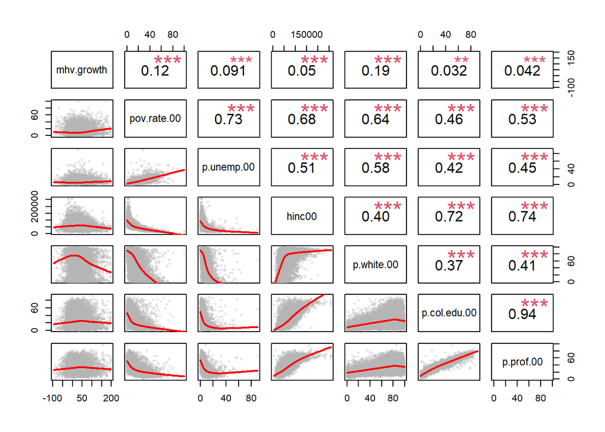

```r
# Select predictors of change in MHV or mhv.growth

d_predict <- select(d_clean, mhv.growth, pov.rate.00, p.unemp.00, hinc00, p.white.00, p.col.edu.00, p.prof.00)

# reduce data density for visualization
set.seed( 1234 )
d1 <- sample_n( d_predict, 10000 ) %>% na.omit()

# correlation plots
pairs(d1, panel = panel.cor, lower.panel = panel.smooth )
```

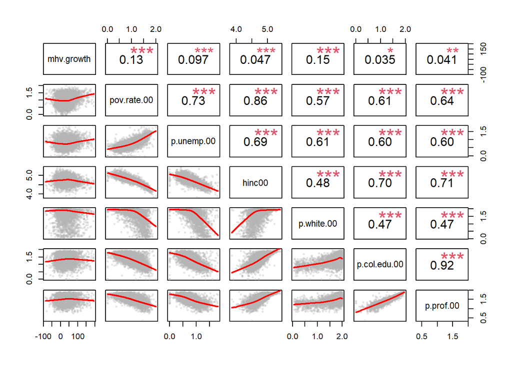

```r
# Perform log transformation to get rid of varibale skew.

# reduce data density for visualization
set.seed( 1234 )

# recode some vars to remove outliers and skew
d_predict$p.unemp.00 <- log10( d_predict$p.unemp.00 + 1 )
d_predict$hinc00 <- log10( d_predict$hinc00 + 1 )
d_predict$p.white.00 <- log10( d_predict$p.white.00 + 1  )
d_predict$pov.rate.00 <- log10( d_predict$pov.rate.00 + 1 )
d_predict$p.col.edu.00 <- log10( d_predict$p.col.edu.00 + 1 )
d_predict$p.prof.00 <- log10( d_predict$p.prof.00 + 1 )


d2 <- sample_n( d_predict, 5000 ) %>% na.omit()

# correlation plots
pairs(d2, panel = panel.cor, lower.panel = panel.smooth )
```

```r
# Test for multicollinearity

m1 <- lm( mhv.growth ~  pov.rate.00, data=d_predict )
m2 <- lm( mhv.growth ~  p.unemp.00, data=d_predict )
m3 <- lm( mhv.growth ~  p.white.00, data=d_predict )
m4 <- lm( mhv.growth ~  p.prof.00, data=d_predict )
m5 <- lm( mhv.growth ~  pov.rate.00 + p.unemp.00 + p.white.00 + p.prof.00, data=d_predict )

stargazer( m1, m2, m3, m4, m5,
           type=S_TYPE, digits=2,
           omit.stat = c("rsq","f") )
```

```
##
## ==================================================================================================================
##                                                          Dependent variable:
##                     ----------------------------------------------------------------------------------------------
##                                                               mhv.growth
##                            (1)                (2)                (3)                (4)                (5)
## ------------------------------------------------------------------------------------------------------------------
## pov.rate.00              12.78***                                                                    14.58***
##                           (0.42)                                                                      (0.66)
##
## p.unemp.00                                  15.58***                                                 4.10***
##                                              (0.56)                                                   (0.88)
##
## p.white.00                                                    -14.80***                             -15.21***
##                                                                 (0.35)                                (0.45)
##
## p.prof.00                                                                         5.16***            39.56***
##                                                                                    (0.74)             (0.96)
##
## Constant                 16.77***           17.36***           54.88***           21.64***          -21.25***
##                           (0.44)             (0.46)             (0.62)             (1.12)             (2.09)
##
## ------------------------------------------------------------------------------------------------------------------
## Observations              58,566             58,566             58,566             58,566             58,566
## Adjusted R2                0.02               0.01               0.03              0.001               0.06
## Residual Std. Error 34.70 (df = 58564) 34.75 (df = 58564) 34.45 (df = 58564) 34.97 (df = 58564) 33.94 (df = 58561)
## ==================================================================================================================
## Note:                                                                                  *p<0.1; **p<0.05; ***p<0.01
```

```r
# Remove p.unemp and run the regression model again.

m6 <- lm( mhv.growth ~  pov.rate.00 + p.white.00 + p.prof.00, data=d_predict )

stargazer( m1, m3, m4, m6,
           type=S_TYPE, digits=2,
           omit.stat = c("rsq","f") )
```

```
##
## ===============================================================================================
##                                                 Dependent variable:
##                     ---------------------------------------------------------------------------
##                                                     mhv.growth
##                            (1)                (2)                (3)                (4)
## -----------------------------------------------------------------------------------------------
## pov.rate.00              12.78***                                                 16.08***
##                           (0.42)                                                   (0.58)
##
## p.white.00                                 -14.80***                             -15.86***
##                                              (0.35)                                (0.42)
##
## p.prof.00                                                      5.16***            38.75***
##                                                                 (0.74)             (0.94)
##
## Constant                 16.77***           54.88***           21.64***          -17.24***
##                           (0.44)             (0.62)             (1.12)             (1.91)
##
## -----------------------------------------------------------------------------------------------
## Observations              58,566             58,566             58,566             58,566
## Adjusted R2                0.02               0.03              0.001               0.06
## Residual Std. Error 34.70 (df = 58564) 34.45 (df = 58564) 34.97 (df = 58564) 33.95 (df = 58562)
## ===============================================================================================
## Note:                                                               *p<0.1; **p<0.05; ***p<0.01
```

```r
# Add a metro-level control

d_fixed <-
  d_clean %>%
  group_by( cbsaname ) %>%
  mutate( metro.mhv.growth = 100 * median( mhv.growth, na.rm=T ) ) %>%
  ungroup()

# Select variables for regression model.
d.reg <- select(d_fixed, mhv.growth, pov.rate.00, p.white.00, p.prof.00, cbsa)


# Perform log transformations
d.reg$p.white <- log10( d.reg$p.white.00 + 1  )
d.reg$pov.rate <- log10( d.reg$pov.rate.00 + 1 )
d.reg$p.prof <- log10( d.reg$p.prof.00 + 1 )

# Regression Model
m1 <- lm( mhv.growth ~  pov.rate, data=d.reg )
m2 <- lm( mhv.growth ~  p.white, data=d.reg )
m3 <- lm( mhv.growth ~  p.prof, data=d.reg )
m4 <- lm( mhv.growth ~  pov.rate + p.white + p.prof + cbsa, data=d.reg )

stargazer( m1, m2, m3, m4,
           type=S_TYPE, digits=2,
           omit.stat = c("rsq","f"),
           omit="cbsa",
           add.lines = list(c("Metro Fixed Effects:", "NO", "NO", "NO", "YES")) )
```

```
##
## ================================================================================================
##                                                  Dependent variable:
##                      ---------------------------------------------------------------------------
##                                                      mhv.growth
##                             (1)                (2)                (3)                (4)
## ------------------------------------------------------------------------------------------------
## pov.rate                  12.78***                                                 13.74***
##                            (0.42)                                                   (0.48)
##
## p.white                                     -14.80***                              -1.37***
##                                               (0.35)                                (0.40)
##
## p.prof                                                          5.16***            10.14***
##                                                                  (0.74)             (0.80)
##
## Constant                  16.77***           54.88***           21.64***            -4.80
##                            (0.44)             (0.62)             (1.12)             (4.40)
##
## ------------------------------------------------------------------------------------------------
## Metro Fixed Effects:         NO                 NO                 NO                YES
## Observations               58,566             58,566             58,566             58,566
## Adjusted R2                 0.02               0.03              0.001               0.43
## Residual Std. Error  34.70 (df = 58564) 34.45 (df = 58564) 34.97 (df = 58564) 26.45 (df = 58184)
## ================================================================================================
## Note:                                                                *p<0.1; **p<0.05; ***p<0.01
```

The higher the poverty rate in a metro area, the more growth they will experience in median home value. This result makes the most sense to me based on what we have learned about gentrification. Median home value will grow at a quicker rate (or higher percentage) in a metropolitan area where the poverty rate was already high compared to a richer area.

The higher the percentage of whites in the population in 2000, the less growth in median home value a tract or metro area will experience.However, upon adding the cbsa variable to create a metro-level fixed effect, the coefficient decreases immensely. This indicates that the percent of white in the population has different effects on median home value growth depending on the tract. This should be investigated further.

The higher the percentage of professional employees in the population in 2000, the more growth they will experience in median home value. This result makes less sense to me since it conceptually contradicts the trend seen with poverty rates. The increase in the coefficient in the fourth model is also concerning.

It is also interesting to see that all the variables I selected are significant.